# Analyzing Pollution and Weather Variables Using Principal Component Analysis

Joshua Zhong

7/23/2024

# 1 Introduction

Air pollution is a significant environmental and public health issue, with several variables influencing pollution levels, such as weather conditions and population density. Understanding the relationships between these variables can provide insights into patterns of pollution and help in designing mitigation strategies.

In this analysis, we aim to explore and reduce the dimensionality of a dataset containing air pollution and weather-related variables using Principal Component Analysis (PCA). PCA is a statistical tool that allows us to simplify complex data by transforming the original variables into a smaller set of uncorrelated components that retain most of the information. By applying PCA, we aim to:

- Identify the key factors driving variation in pollution and weather conditions.
- Simplify the dataset by reducing redundancy due to highly correlated variables.

## 1.1 Research Question

Can we identify the primary components that explain the variability in pollution and weather-related data, and how does scaling affect the contributions of different variables to these components?

# 2 Methods

## 2.1 Principal Component Analysis (PCA)

PCA is a technique used to reduce the dimensionality of large datasets by transforming the original variables into a new set of variables, known as principal components. These components are linear combinations of the original variables and are uncorrelated with each other.

PCA achieves dimensionality reduction by finding the directions (principal components) that maximize the variance in the data. The first principal component (PC1) accounts for the largest portion of the variance, and each subsequent component accounts for progressively less variance. By keeping only the first few components, we can retain most of the information from the original dataset while reducing its complexity.

### 2.1.1 Rationale for Using PCA

- **Correlation between variables**: PCA is useful in handling variables that are highly correlated. PCA helps reduce this redundancy.
- **Dimensionality reduction**: By reducing the number of variables, we aim to make the data easier to interpret and more manageable while retaining most of its variance.
- **Data simplification**: We aim to identify key factors influencing pollution without losing important information.

### 2.1.2 Assumptions of PCA:

- **Linearity**: PCA assumes that the relationships between variables are linear.
- **Large variances capture more information**: PCA prioritizes components that explain the largest variance.
- **Mean-centered data**: PCA requires that the data be centered around the mean.

### 2.1.3 Scaling in PCA:

Scaling ensures that all variables contribute equally to the analysis. If the variables have different units or variances, PCA without scaling can be biased towards variables with larger variances. However, PCA without scaling might be appropriate when all variables are measured on the same scale or when we want to retain the influence of variables with naturally larger variances. In this case, scaling is applied because the variables are measured in different units, and we want each variable to contribute equally to the analysis.

# 3 Data Description

The dataset used in this analysis consists of seven variables related to air pollution and weather conditions:

- SO2: Levels of sulfur dioxide
- temp: Temperature in the region
- manu: Manufacturing levels
- popul: Population size
- precip: Precipitation levels
- wind: Wind speed
- predays: Number of precipitation days

These variables are selected to capture key factors influencing pollution. PCA will help us explore the relationships among these variables and identify the main drivers of variability in the data.

The link to the raw CSV file is posted on GitHub: https://raw.githubusercontent.com/JZhong01/STA419/refs/heads/main/HW2data.csv.

```r
# Load data
pollution <- read.csv("https://raw.githubusercontent.com/JZhong01/STA419/refs/heads/main/HW2data.csv", header = TRUE)

pollution.quant <- select(pollution, SO2, temp, manu, popul, precip, wind, predays)
str(pollution.quant)
'data.frame':   41 obs. of  7 variables:
 $ SO2    : int  46 11 24 47 11 31 110 23 65 26 ...
 $ temp   : num  47.6 56.8 61.5 55 47.1 55.2 50.6 54 49.7 51.5 ...
 $ manu   : int  44 46 368 625 391 35 3344 462 1007 266 ...
 $ popul  : int  116 244 497 905 463 71 3369 453 751 540 ...
 $ precip : num  33.36 7.77 48.34 41.31 36.11 ...
 $ wind   : num  8.8 8.9 9.1 9.6 12.4 6.5 10.4 7.1 10.9 8.6 ...
 $ predays: int  135 58 115 111 166 148 122 132 155 134 ...
```

# 4 Exploratory Data Analysis

Before applying PCA, we examine the relationships between the selected variables using pairwise correlation and visualization. This helps to understand the correlations between variables and gives insight into which variables may be driving similar patterns.

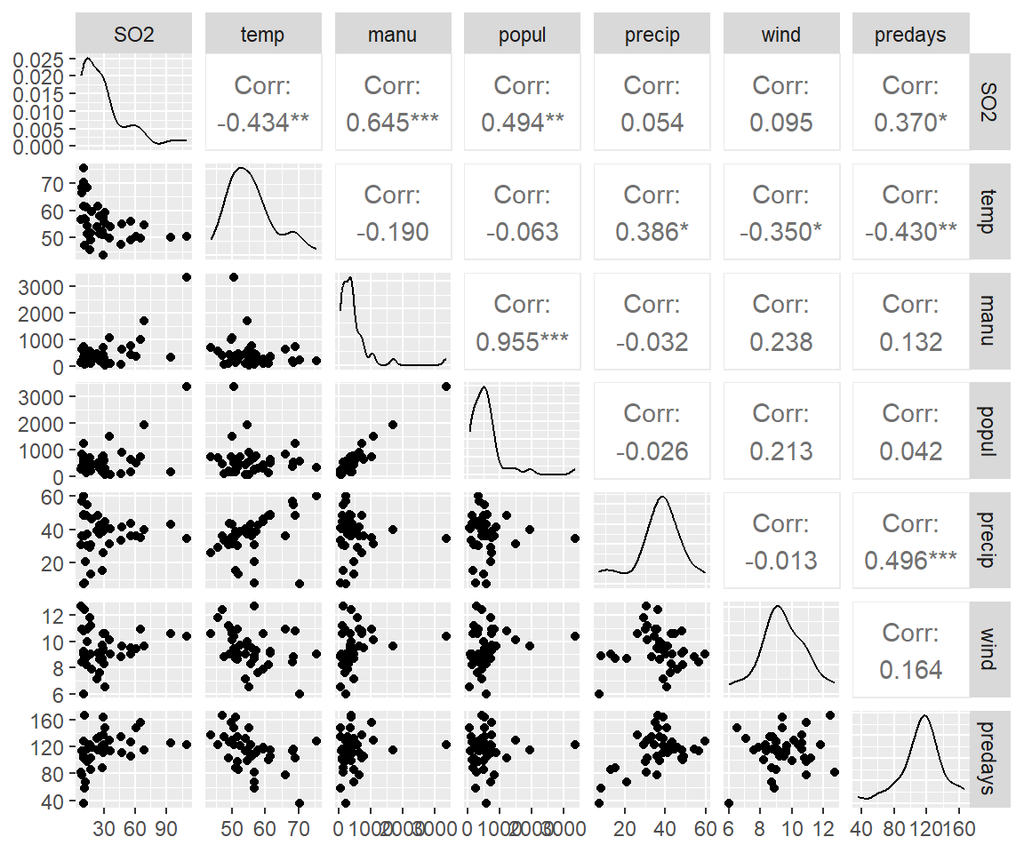

```r
# Visualizing pairwise relationships
ggpairs(pollution.quant)
```

**Key Findings**:

- Strong positive correlation: Manufacturing (manu) and population (popul) have a correlation of r = 0.955.
- Moderate negative correlation: Temperature (temp) and SO2 levels have a correlation of r = -0.434.

These relationships indicate that some variables may be redundant. Highly correlated variables, such as manufacturing and population, may contribute similarly to the variance in the data, which PCA can help to address.

Pairwise correlations are important to check before applying PCA, as PCA is sensitive to correlated variables. High correlations may cause certain variables to dominate the first principal component if scaling is not applied.

# 5 Principal Component Analysis (PCA)

PCA is applied to reduce the dimensionality of the dataset. We begin by performing PCA **without scaling** the variables, followed by PCA **with scaling** to compare the results.

## 5.1 PCA without Scaling

```r
# Perform PCA without scaling
pca <- prcomp(pollution.quant)
summary(pca)
Importance of components:
                            PC1       PC2      PC3      PC4      PC5     PC6
Standard deviation     799.0444 121.70472 26.49453 14.31789 10.80299 3.47233
Proportion of Variance   0.9758   0.02264  0.00107  0.00031  0.00018 0.00002
Cumulative Proportion    0.9758   0.99841  0.99949  0.99980  0.99998 1.00000
                         PC7
Standard deviation     1.204
Proportion of Variance 0.000
Cumulative Proportion  1.000
```

**Results**:

The first principal component (PC1) explains 97.58% of the total variance, and the first two components together explain 99.8% of the variance. This high variance explained by PC1 suggests that variables with larger variances, like manufacturing and population, dominate the analysis. This can be problematic as it may mask the contribution of other important variables with smaller variances, such as temperature or precipitation.

## 5.2 PCA with Scaling

Next, we apply PCA with scaled variables to account for differences in units and variances.

```r
# Perform PCA with scaling
pca.sc <- prcomp(pollution.quant, scale = TRUE)
summary(pca.sc)
Importance of components:
                          PC1    PC2    PC3    PC4     PC5     PC6     PC7
Standard deviation     1.6517 1.2298 1.1811 0.9445 0.58888 0.31668 0.15973
Proportion of Variance 0.3897 0.2160 0.1993 0.1274 0.04954 0.01433 0.00364
Cumulative Proportion  0.3897 0.6058 0.8051 0.9325 0.98203 0.99636 1.00000
```

**Results**:

- After scaling, PC1 explains **38.97%** of the variance, and the first two components explain **60.58%**.

Scaling balances the contribution of each variable by giving them equal weight. This prevents variables with larger variances, such as manufacturing and population, from dominating the analysis. After scaling, more variables contribute meaningfully to the first few components.

# 6 Results and Interpretation

## 6.1 Principal Component Loadings

The loadings of each variable on the principal components provide insight into how much each variable contributes to each component.

### 6.1.1 Loadings without Scaling:

```r
pca$rotation
                  PC1          PC2          PC3         PC4          PC5
SO2     -0.0168607518  0.099835625  0.208775573 -0.95883106  0.152191203
temp     0.0011417794 -0.025814390 -0.071600745  0.11014784  0.477854201
manu    -0.6968327936  0.710249079 -0.067182201  0.07319788  0.009643654
popul   -0.7170284512 -0.692912523  0.056666935 -0.04906669 -0.010735457
precip   0.0004336922 -0.001225937  0.265807619  0.16261712  0.832729325
wind    -0.0004067530  0.001011680  0.005386606  0.01506609 -0.025401917
predays -0.0028836950  0.069155051  0.934279828  0.18459052 -0.232812295
                 PC6            PC7
SO2      0.053952911  0.02704137589
temp     0.852534945  0.16405069781
manu     0.002153023 -0.00113620790
popul   -0.002915751  0.00005682006
precip  -0.453206155 -0.06376787701
wind    -0.176541256  0.98383470979
predays  0.183568735  0.01891454497
```

### 6.1.2 Loadings with Scaling:

```r
pca.sc$rotation
                  PC1         PC2        PC3         PC4        PC5         PC6
SO2     -0.4896988171 -0.08457563  0.0143502 -0.40421007 -0.7303942  0.18334573
temp     0.3153706901  0.08863789  0.6771362  0.18522794 -0.1624652  0.61066107
manu    -0.5411687028  0.22588109  0.2671591  0.02627237  0.1641011 -0.04273352
popul   -0.4875881115  0.28200380  0.3448380  0.11340377  0.3491048 -0.08786327
precip  -0.0001873122 -0.62587937  0.4920363  0.18393719 -0.1605988 -0.55357384
wind    -0.2498749284 -0.05547149 -0.3112655  0.86190131 -0.2682549  0.15005378
predays -0.2601790729 -0.67796741 -0.1095789 -0.10976070  0.4399698  0.50494668
                 PC7
SO2      0.149529278
temp    -0.023664113
manu    -0.745180920
popul    0.649125507
precip  -0.010315309
wind     0.015765377
predays  0.008217393
```

**Interpretation**:

Without scaling, the largest loadings in PC1 are from manufacturing and population, due to their large variances. Loadings represent the contribution of each variable to the principal components, with higher absolute loadings indicating greater influence. This means that manufacturing and population heavily contribute to PC1, while other variables have a smaller influence.

With scaling, the loadings are more balanced across the variables. Temperature, for example, has a stronger contribution to PC1 after scaling, indicating that it becomes a more important factor when variables are standardized. In this case, the variables contribute more equally, providing a more balanced picture of the data.

## 6.2 Biplot

To further visualize the relationships between variables and the first two principal components, we create a biplot.

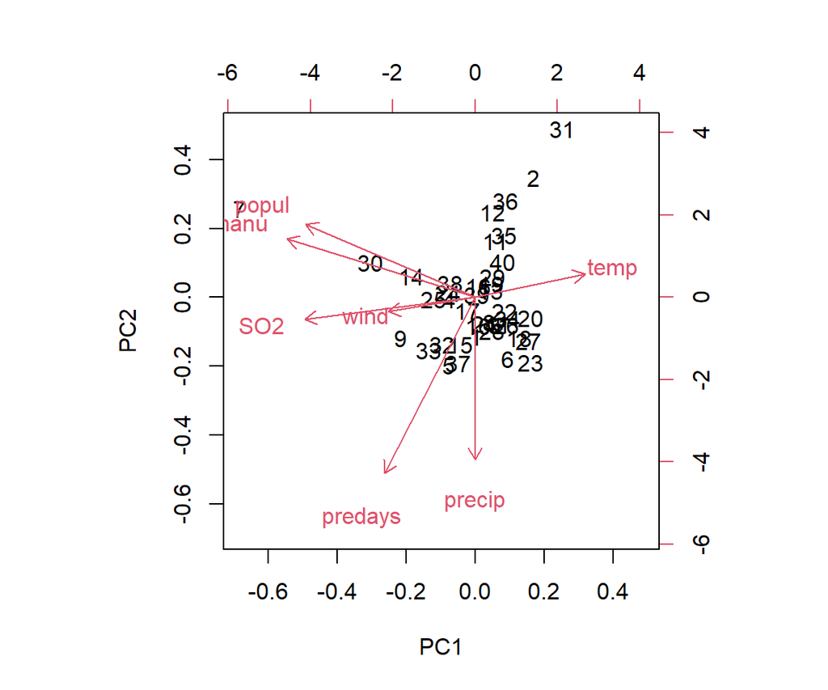

```r
# Create biplot for scaled PCA
biplot(pca.sc)
```

**Interpretation**:

The arrows represent the variables, with their directions and lengths indicating the contributions to the principal components. For example, SO2, manu, and popul show strong contributions to PC1, while precip and predays contribute more to PC2. Additionally, the angles between the arrows provide insights into the correlations between variables. Acute angles suggest a positive correlation, while obtuse angles suggest a negative correlation.

The scaling of the data ensures that variables with smaller variances, such as temperature and wind, are represented more equally in the biplot.

# 7 Conclusion

In this analysis, Principal Component Analysis (PCA) was used to reduce the dimensionality of a dataset containing pollution and weather variables. Our research question aimed to identify the primary components driving variability in the data and understand how scaling affects the results of PCA.

The analysis revealed that **without scaling**, the first principal component (PC1) explained 97.58% of the total variance, primarily driven by **manufacturing** and **population** variables due to their large variances. This dominance of these variables highlights that unscaled PCA disproportionately favors variables with higher variances, potentially masking the contributions of other important variables, such as **temperature** or **precipitation**.

However, **after scaling**, the results were more balanced. The first principal component (PC1) explained 38.97% of the variance, with the second component adding another 21.61%. Scaling allowed variables like **temperature**, **SO2**, and **precipitation days** to contribute more meaningfully to the analysis, offering a more nuanced and equitable view of the dataset.

## 7.1 Answering the Research Question:

The findings indicate that **manufacturing** and **population** are key contributors to the variability in pollution and weather data, particularly when considered without scaling. This suggests that these variables are highly influential in shaping pollution levels, potentially due to industrial activity and urban density.

However, after scaling, **temperature** and **precipitation days** emerged as important contributors, implying that **weather patterns** also play a significant role in influencing pollution levels. These findings suggest that both industrial activity and environmental factors must be considered when analyzing air pollution data and devising mitigation strategies.

## 7.2 Implications:

The implications of this analysis are twofold:

1. **For policymakers**: The strong influence of **manufacturing** and **population** on pollution highlights the need for targeted regulations and interventions in areas with high industrial activity and dense populations. Additionally, environmental factors such as **temperature** and **precipitation** also need to be integrated into pollution control strategies.
2. **For future research**: The results suggest that further analysis should explore the interplay between **human activities** and **weather conditions** in shaping pollution dynamics. Identifying specific thresholds or interactions between these factors may offer more precise insights into pollution control measures.

Overall, PCA has proven to be a valuable tool for reducing dimensionality and highlighting the most important factors influencing pollution in this dataset. The benefits of scaling underscore the importance of ensuring that all variables are treated equitably in multivariate analyses. Future research could explore different scaling techniques, such as Z-score or Min-Max scaling, to examine whether they influence the results of PCA in this context or apply methods like cross-validation to test the robustness of the PCA model and ensure that the principal components are stable across different data subsets.